# Amelia Vargas

Hi! I’m Amelia, a data scientist based in the Pacific Northwest.

I work for an insurance company based in Oregon, solving hard problems with creativity and curiosity. Previously, I worked in public service with the State of Oregon as a Senior Research Analyst.

# Organizations

I’m a member of the [State of Oregon Research Academy](https://oregonresearch.org/executive-committee/) (SORA) Executive Committee.

# Education

M.Sc. in Mathematics from [Dalhousie University, Canada](https://www.dal.ca/faculty/science/math-stats.html)

M.Sc. thesis: *A Geometric Study of Superintegrable Systems* [[arXiv](https://arxiv.org/abs/1209.5672)]

B.Sc. in Physics and B.A. in Mathematics from [California State University, Fullerton, USA](https://www.fullerton.edu/nsm/)

# Studies

*A remark on the Tremblay-Turbiner-Winternitz potential*  
R. Smirnov, A. Vargas  
Journal of Physics: Conference Series, Volume 2912, The XXVIII International Conference on Integrable Systems and Quantum Symmetries (2024)  
[PDF](https://iopscience.iop.org/article/10.1088/1742-6596/2912/1/012039)

*2022 Oregon Workers’ Compensation Premium Rate Ranking Study*  
D. Gallogly, A. Vargas  
[PDF](https://www.oregon.gov/dcbs/reports/Documents/general/prem-rpt/22-2083.pdf)

*Statistical analysis of reporting of student genders in Oregon’s public schools*  
A. Vargas, A. Vargas  
2018 Oregon Statewide Annual Report Card.  
[ODE](https://www.oregon.gov/ode/schools-and-districts/reportcards/pages/statewide-annual-report-card.aspx)

*Newspaper Archives + Text Mining = Rich Sources of Historical Geospatial Data: A Flood Database Case Study*  
A. Yzaguirre, R. Warren, M. Smit  
IOP Conference Series: Earth and Environmental Science, Volume 34, conference 1 (2016).  
[IOP Science](http://iopscience.iop.org/article/10.1088/1755-1315/34/1/012043)

*Detecting environmental disasters in digital news archives*  
A. Yzaguirre, R. Warren, M. Smit  
2015 IEEE International Conference on Big Data (Big Data), pp. 2027-2035 (2015).  
[IEEE Xplore Digital Library](https://ieeexplore.ieee.org/document/7363984/)

*Infrared Spectral Energy Distributions of Seyfert Galaxies: Spitzer Space Telescope Observations of the 12 micron Sample of Active Galaxies*  
J. F. Gallimore, A. L. Yzaguirre, J. Jakoboski, M. J. Stevenosky, D. J. Axon, S. A. Baum, C. L. Buchanan, M. Elitzur, M. Elvis, C. P. O’Dea, A. Robinson  
The Astrophysical Journal Supplement Series, Volume 187, Issue 1, pp. 172-211 (2010).  
[arXiv](https://arxiv.org/abs/1001.4974)

*Cosmic topology: Studying the shape and size of our universe*  
A. Yzaguirre, A. Hajian  
Bulletin of the American Astronomical Society, vol. 42, p. 549 (2010).  
[SAO/NASA ADS Astronomy Abstract Service](https://ui.adsabs.harvard.edu/abs/2010AAS...21536201Y/abstract)

# Recommendations

- [DevOps for Data Science](https://do4ds.com/) by Alex K. Gold
- [How to Solve It](https://bookshop.org/p/books/how-to-solve-it-a-new-aspect-of-mathematical-method-g-polya/8945392) by George Pólya.
- [Statistical Rethinking](https://xcelab.net/rm/statistical-rethinking/) by Richard McElreath.
- [{tidymodels}](https://www.tidymodels.org/) and [Tidy Modeling with R](https://www.tmwr.org/) by Max Kuhn & Julia Silge
- [Applied Predictive Modeling](http://appliedpredictivemodeling.com/) by Kuhn & Johnson
- Coffee, boba, and chocolate.

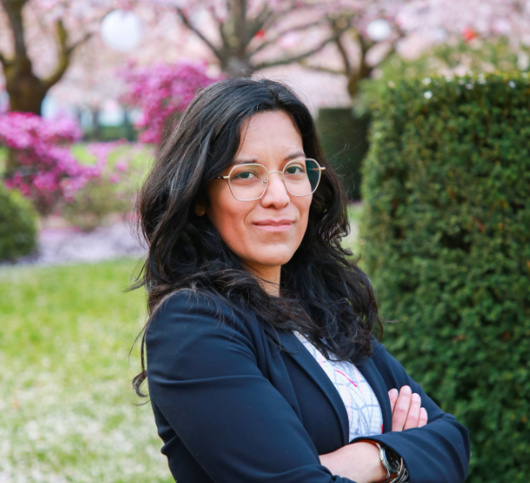